# Stats with R tutorial

#### Challenge 3: use ggplot to make a new plot of this effect

## RESEARCH AIM 5: total_behaviour_score ~ age + sex + genotype (multiple linear regression)

This is were we start to add covariates and do multiple regression

```r
lm3 <- ols(data=alldata, totalcog_pT ~ age + genotype + sex)
anova(lm3)
```

```
##                 Analysis of Variance          Response: totalcog_pT
##
##  Factor     d.f. Partial SS   MS           F     P
##  age          1  8.449950e-04 8.449950e-04 14.68 0.0002
##  genotype     2  6.737907e-05 3.368954e-05  0.59 0.5576
##  sex          1  2.106451e-04 2.106451e-04  3.66 0.0567
##  REGRESSION   4  1.115625e-03 2.789063e-04  4.85 0.0008
##  ERROR      309  1.778648e-02 5.756143e-05
```

```r
summary(lm3)
```

```
##              Effects              Response : totalcog_pT
##
##  Factor            Low High Diff. Effect S.E. Lower 0.95 Upper 0.95
##  age               43  58   15    0      0    0          0
##  genotype - AA:AG   2   1   NA    0      0    0          0
##  genotype - GG:AG   2   3   NA    0      0    0          0
##  sex - Male:Female  2   1   NA    0      0    0          0
```

We can easily visualise the effects of each variable on the outcome using rms, but this feature does not give us plot points and is not very flexible:

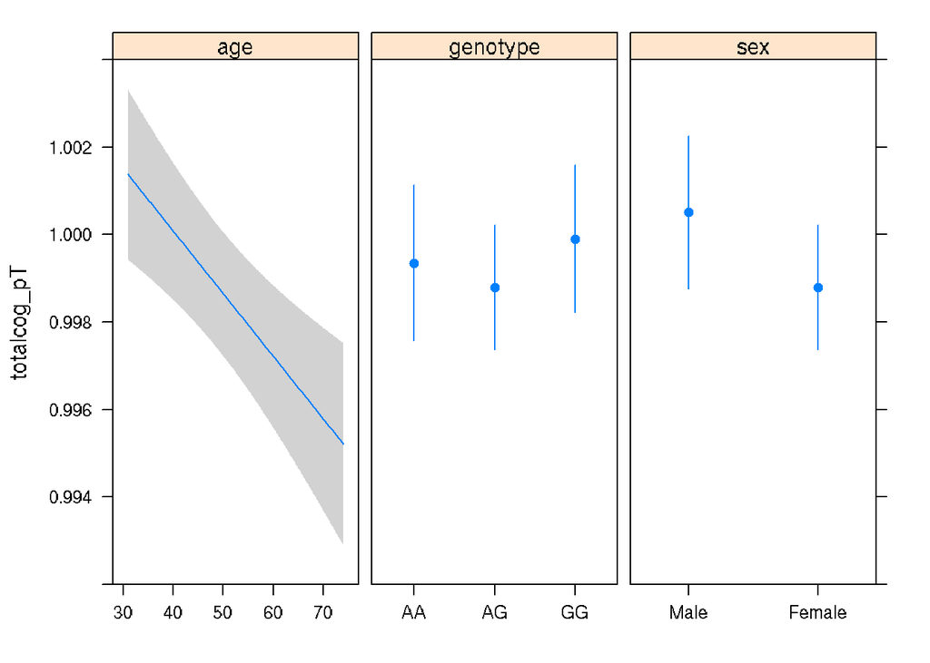

```r
plot(Predict(lm3))
```

Now let’s say we want to recode out genotype variable so that we have only 2 groups: those who “carry” the G allele, and those who do not carry it:

```r
alldata$riskcarrier[alldata$genotype=="AG" | alldata$genotype=="GG"] <- "carrier"
alldata$riskcarrier[alldata$genotype=="AA"] <- "non-carrier"
alldata$riskcarrier <- as.factor(alldata$riskcarrier)
```

No we can re-run the model:

```r
dd.alldata <- datadist(alldata)
options(datadist="dd.alldata")
lm3 <- ols(data=alldata, totalcog_pT ~ age + sex + riskcarrier)
lm3
```

```
##
## Linear Regression Model
##
## ols(formula = totalcog_pT ~ age + sex + riskcarrier, data = alldata)
##
## Frequencies of Missing Values Due to Each Variable
## totalcog_pT         age         sex riskcarrier
##          18           8           4           8
##
##
##                 Model Likelihood     Discrimination
##                    Ratio Test           Indexes
## Obs      314    LR chi2     17.93    R2       0.055
## sigma 0.0076    d.f.            3    R2 adj   0.046
## d.f.     310    Pr(> chi2) 0.0005    g        0.002
##
## Residuals
##
##        Min         1Q     Median         3Q        Max
## -1.761e-02 -5.765e-03 -7.513e-05  6.148e-03  1.767e-02
##
##                         Coef    S.E.   t      Pr(>|t|)
## Intercept                1.0080 0.0020 500.39 <0.0001
## age                     -0.0001 0.0000  -3.83 0.0002
## sex=Female              -0.0017 0.0009  -1.93 0.0548
## riskcarrier=non-carrier  0.0001 0.0010   0.12 0.9074
```

```r
anova(lm3)
```

```
##                 Analysis of Variance          Response: totalcog_pT
##
##  Factor      d.f. Partial SS   MS           F     P
##  age           1  8.468547e-04 8.468547e-04 14.70 0.0002
##  sex           1  2.140203e-04 2.140203e-04  3.72 0.0548
##  riskcarrier   1  7.802082e-07 7.802082e-07  0.01 0.9074
##  REGRESSION    3  1.049026e-03 3.496754e-04  6.07 0.0005
##  ERROR       310  1.785308e-02 5.759059e-05
```

```r
summary(lm3)
```

```
##              Effects              Response : totalcog_pT
##
##  Factor                            Low High Diff. Effect S.E. Lower 0.95
##  age                               43  58   15    0      0    0
##  sex - Male:Female                  2   1   NA    0      0    0
##  riskcarrier - non-carrier:carrier  1   2   NA    0      0    0
##  Upper 0.95
##  0
##  0
##  0
```

## RESEARCH AIM 5: Interaction!

#### total_behaviour_score ~ age*riskcarrier + sex

The concept of statistical interaction goes by many names and has many definitions. Simply this is the concept that the effect of one variable changes depending on the value of another variable.

Interaction is indicated in R formula syntax with a “:” or `*`, depending on if you want to automatically include the main effects of your interacting variables or not. As a general rule, always use `*`.

```r
lm4 <- lm(totalcog_pT ~ sex + riskcarrier*age, data=alldata)
summary(lm4)
```

```
##
## Call:
## lm(formula = totalcog_pT ~ sex + riskcarrier * age, data = alldata)
##
## Residuals:
##        Min         1Q     Median         3Q        Max
## -0.0176521 -0.0056722 -0.0004349  0.0057920  0.0181582
##
## Coefficients:
##                              Estimate Std. Error t value Pr(>|t|)
## (Intercept)                 1.010e+00  2.301e-03 438.920  < 2e-16 ***
## sexFemale                  -1.727e-03  8.935e-04  -1.933   0.0541 .
## riskcarriernon-carrier     -6.756e-03  4.504e-03  -1.500   0.1346
## age                        -1.790e-04  4.372e-05  -4.095  5.4e-05 ***
## riskcarriernon-carrier:age  1.312e-04  8.402e-05   1.561   0.1195
## ---
## Signif. codes:  0 '***' 0.001 '**' 0.01 '*' 0.05 '.' 0.1 ' ' 1
##
## Residual standard error: 0.007571 on 309 degrees of freedom
##   (36 observations deleted due to missingness)
## Multiple R-squared:  0.06289,    Adjusted R-squared:  0.05076
## F-statistic: 5.184 on 4 and 309 DF,  p-value: 0.0004697
```

```r
anova(lm4)
```

```
## Analysis of Variance Table
##
## Response: totalcog_pT
##                  Df    Sum Sq    Mean Sq F value    Pr(>F)
## sex               1 0.0001862 0.00018620  3.2482 0.0724769 .
## riskcarrier       1 0.0000160 0.00001597  0.2786 0.5980138
## age               1 0.0008469 0.00084685 14.7729 0.0001472 ***
## riskcarrier:age   1 0.0001397 0.00013968  2.4367 0.1195489
## Residuals       309 0.0177134 0.00005732
## ---
## Signif. codes:  0 '***' 0.001 '**' 0.01 '*' 0.05 '.' 0.1 ' ' 1
```

# BONUS SECTION - the “right” way to plot….

## How to visualize a significant effect from our regression

####…Controlling for the other variables in the model….

To visualize a given effect more informatively, we want to caculate the residuals of the model lacking our co-varitate of interest and plot those residuals as our outcome:

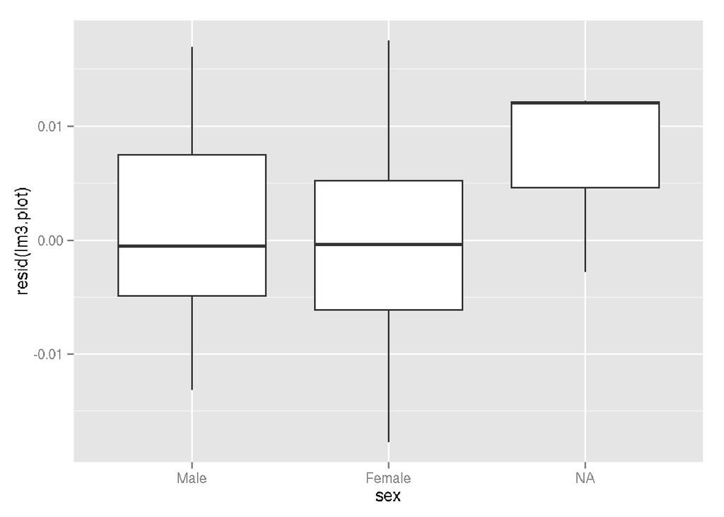

```r
lm3.plot <- ols(data=alldata, totalcog_pT ~ genotype + age)

ggplot(data=alldata, aes(y=resid(lm3.plot), x=sex)) +
  geom_boxplot()
```

See it thinks NA is a value! That is because the ols() object stores NA input values as NA residuals, and ggplot2 sees these as another level to plot. Fix by re-running the model to exclude missing observations and plotting the data subset where NAs are excluded:

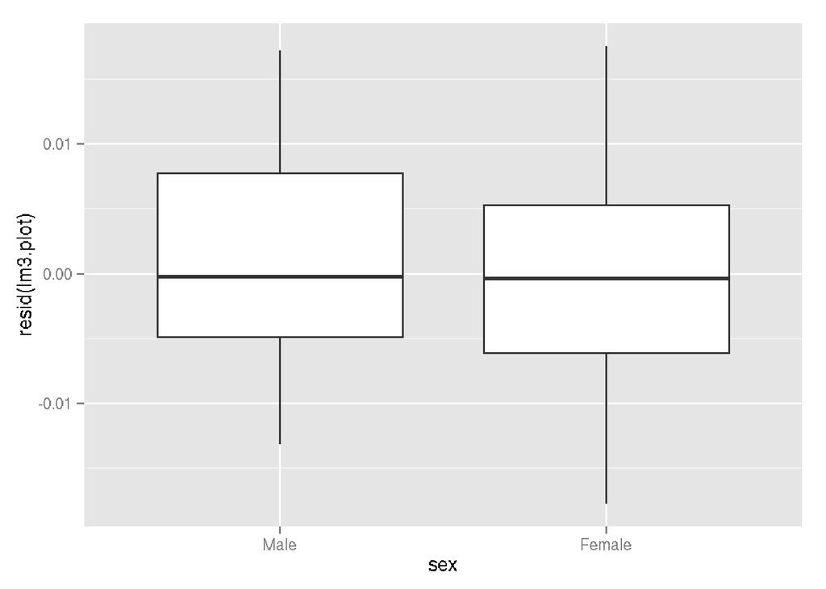

```r
lm3.plot <- ols(data=subset(alldata,sex!="NA"), totalcog_pT ~ age + genotype)
ggplot(data=subset(alldata,sex!="NA"), aes(y=resid(lm3.plot), x=sex)) +
  geom_boxplot()
```

Ror age we want a scatterplot of residuals. same subsetting principle applies:

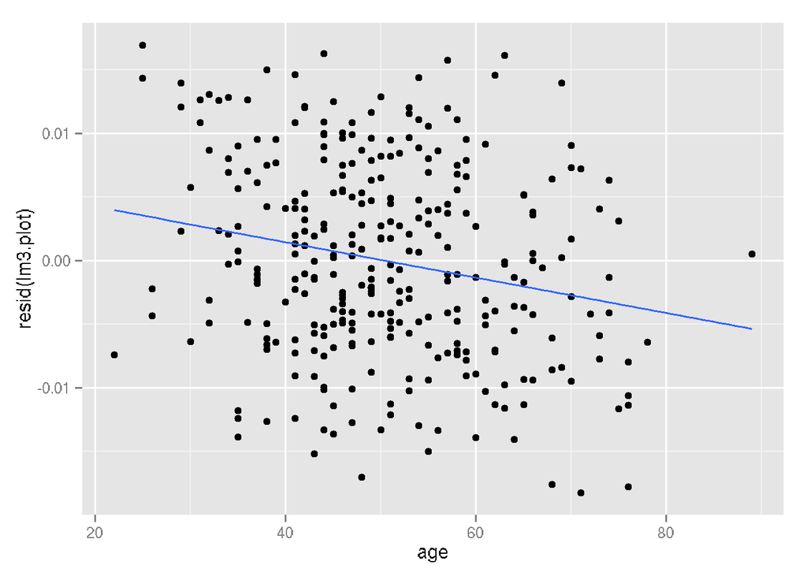

```r
lm3.plot <- ols(data=subset(alldata,age!="NA"), totalcog_pT ~ genotype + sex)
ggplot(data=subset(alldata,age!="NA"), aes(y=resid(lm3.plot), x=age)) +
  geom_point() +
  geom_smooth(method=lm)
```

**CONCEPT**: notice that if we include age in our model and plot age on the x-axis in our residual plot, the effect is lost - we have modeled it out:

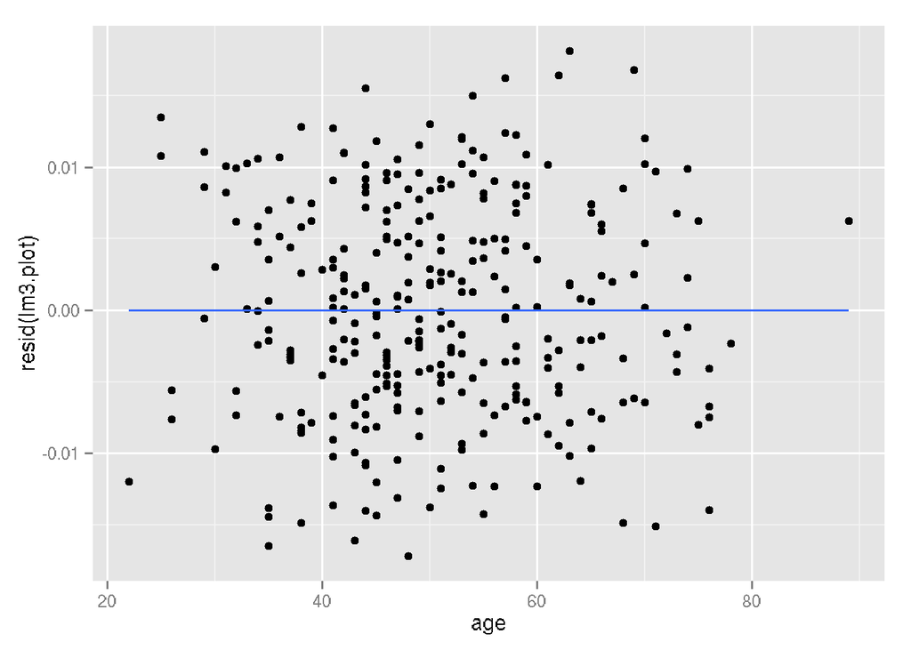

```r
lm3.plot <- ols(data=alldata, totalcog_pT ~ genotype + sex + age)
ggplot(data=alldata, aes(y=resid(lm3.plot), x=age)) +
  geom_point() +
  geom_smooth(method=lm)
```

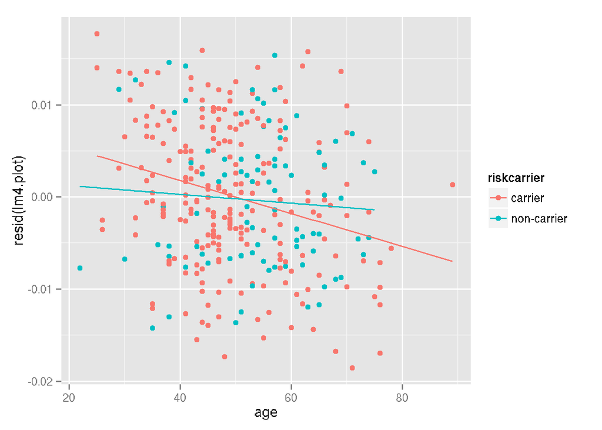

```r
lm4.plot <- ols(data=subset(alldata,age!="NA" & riskcarrier!="NA"), totalcog_pT ~ sex)
ggplot(data=subset(alldata,age!="NA" & riskcarrier!="NA"), aes(y=resid(lm4.plot), x=age, col=riskcarrier)) +
  geom_point() +
  geom_smooth(method=lm)
```